# Lab 6 ANOVA

Tatum Katz, Sam Sambado

2/4/2021

# BACKGROUND

### Analysis of Variance (ANOVA)

We have now seen many different ways to compare the means of two groups. However, what if we have more than two groups? Unfortunately, we can’t just use a bunch of pairwise t-tests because this would inflate our Type I () error. ANOVA is the answer. It gives us a robust and powerful away to determine whether the means of two or more groups are different from each other. There are a couple terms that we need to familiarize ourselves with before we start using ANOVAs.

- **Factor**: Our variable of interest that we are changing. For example, if we were comparing the mean hearing frequency between different felines the factor would be feline and it would have different levels (i.e lion, tiger, and puma).
- **Level/group/treatment**: The levels of a factor are the groups that we are comparing. For example, the levels of the factor feline are lion, tiger, and puma.

### Assumptions of the ANOVA

Here are the assumptions of the ANOVA and how we test them:

1. Measurements from each group (level) represent a random sample from the corresponding population
- Ensure that this assumption is met with your experimental design
2. Our response variable is normally distributed for each population
- Test this assumption with a Q-Q plot and a Shapiro-Wilk test of the residuals
3. The variance is the same in all k populations (homogeneity of variance)
- Test this assumption with a residual plot or a Levene’s Test. We will talk about how to test these assumptions in section 2.2.

### Hypotheses of the ANOVA

If we are comparing the means of k populations, the $H_0$ and $H_A$ of a one-way ANOVA are:

- $H_0$ : The mean of group 1 = mean of group 2 = mean of group k (μ_1= μ_2 = … =μ_k)
- $H_0$ : At least one mean across the groups (μ_j) is not equal

These hypotheses assert that any observation i from group (level) j, y_ij, can be calculated using the following equation: y_ij=μ_j+ϵ_ij

Where ϵ_ij is an error associated with the i measurement from group j and is normally distributed with mean 0 and some variance σ2ϵ. The variance σ2ϵ is constant for all levels. This is just fancy notaiton for restating our two assumptions:

1. Normality
2. Equality of Variance

We could equivalently state the null hypotheses for the ANOVA as $H_0$ :α_1 = α_2 =….= α_j =…= α_k =0

$H_A$ :At least one α_j is not equal to 0

In this case, α_j, is just the deviation of group j from the grand mean μ. The grand mean is the mean of all assumptions pooled across groups. If all these deviations are 0, there is no difference between our means. These hypotheses assert that any observation i from group (level) j, y_ij, can be calculated using the following equation y_ij=μ+α_j+ϵ_ij

If we reject our $H_0$, we have no information about which means are different, just that at least one is different.

**Resources for more R ANOVA tutorials**

- ANOVA blog https://medium.com/@StepUpAnalytics/anova-one-way-vs-two-way-6b3ff87d3a94
- Introduction to ANOVA video https://www.youtube.com/watch?v=FLyCZnjuJVA&feature=youtu.be

# EXERCISES

**A. Washing your hands: Does it help?** Let’s start by asking the following question: Which hand washing method more effectively removes bacteria: washing with water (W), soap (S), anti-bacterial soap (AB), or alcohol (A)? Our factor in this analysis is washing method and it has 4 levels: W, S, AB, A. Our hypotheses are:

- $H_0$: α_W=α_S=α_AB=α_A=0
- $H_A$: At least one α_j is not equal to 0

Always make sure you know what your factor and its levels are before beginning an ANOVA. Otherwise, things can get really confusing. Okay, let’s begin the analysis.

First, lets load in the dataset **hand_washing.csv** and look at it to get a sense of what’s going on.

```r
##read in your data and check out how its structured
hand_wash<-read.csv("hand_washing.csv")

dim(hand_wash) # 32 observations/rows, 2 variables/columns (CLT wouldn't apply)
```

```
## [1] 32  2
```

```r
str(hand_wash) # washing_method = data type is 'chr', we should change it to factor for these analyses
```

```
## 'data.frame':    32 obs. of  2 variables:
##  $ bac_colonies  : int  70 164 88 111 73 119 20 95 51 5 ...
##  $ washing_method: chr  "ab_soap" "ab_soap" "ab_soap" "ab_soap" ...
```

```r
# transform washing_method into a factor
hand_wash$washing_method <- as.factor(hand_wash$washing_method)
str(hand_wash) # washing_method = 'chr', won't work for the mcp()
```

```
## 'data.frame':    32 obs. of  2 variables:
##  $ bac_colonies  : int  70 164 88 111 73 119 20 95 51 5 ...
##  $ washing_method: Factor w/ 4 levels "ab_soap","alcohol",..: 1 1 1 1 1 1 1 1 2 2 ...
```

```r
# another way to see the different levels in a factor
# HINT: unique(dataset$variable)
unique(hand_wash$washing_method) # 4 levels
```

```
## [1] ab_soap alcohol soap    water
## Levels: ab_soap alcohol soap water
```

You’re going to need to use the car and mulcomp packages. You should have the car package already installed, if you’ve done that before you can just use uncomment and run the library() line for car. However for multcomp you will need to install the package first and then call it with library.

```r
library(car)
## Loading required package: carData
#install.packages("multcomp")
library(multcomp)
```

Now lets visualize the data with a boxplot:

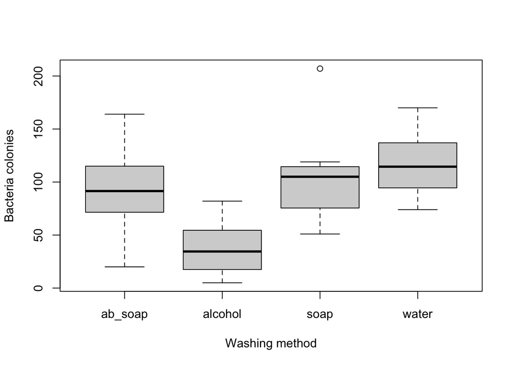

```r
boxplot(bac_colonies~washing_method,
        data=hand_wash,
        xlab="Washing method",ylab="Bacteria colonies") #one outlier
```

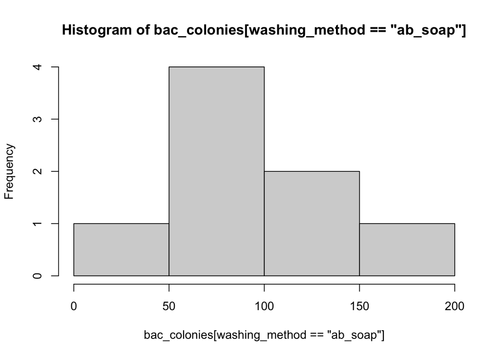

```r
with(hand_wash,hist(bac_colonies[washing_method=="ab_soap"])) # remember [ ] selects for objects
```

Notice that in general, the variances of each level seem pretty comparable in the boxplot. Moreover, the data don’t look like they violate normality too severely, though there is one outlier.

### Checking our assumptions

To test our assumption we need to look at the **residuals** of our ANOVA model. Residuals are defined as:eij=yij−yj¯

In words, this says the residual eij is equal to the *observed* value (yij) minus the *predicted* value (ŷ ij−y¯js)

Reiduals are useful for testing our assumptions because they are estimates of our error terms ϵij. Therefore we should expect that our residuals should be normally distributed and that they should have approximately equal variances.

**For more info on residuals:** http://www.statsmakemecry.com/smmctheblog/confusing-stats-terms-explained-residual.html

To get our residuals, we first need to run our ANOVA. We will use the funciton **aov()** which is very similar in terms of output and structure to lm(), but will calculate ANOVA results instead of regression results!

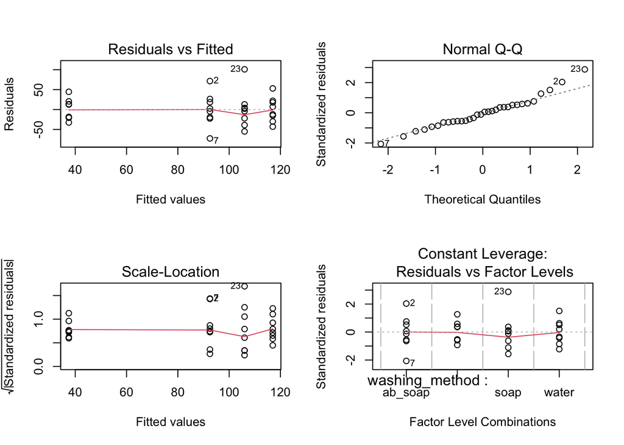

```r
# HINT: aov(y ~ x, data = dataset)
wash1 <- aov(bac_colonies~washing_method, data=hand_wash) #run the ANOVA
par(mfrow=c(2,2)) # places 2 plots on 1 output view
plot(wash1) #look at the diagnostic plots; focus on the first two plots (fitted vs residuals & QQ plot)
```

```r
par(mfrow=c(1,1)) # resets output view
res=wash1$residuals #retrieve the residuals
```

While all the plots on this graph are useful, the two that we will focus on are the plots in the first row.

We have run the ANOVA model! Be warned, we cannot interpret the results until we check the residuals! R has been incredibly helpful and already calculated the residuals for us. Now our residuals are saved in the variable res. With this done, let’s check some of our assumptions.

**Normality**: Run a Shapiro-Wilk test on res.

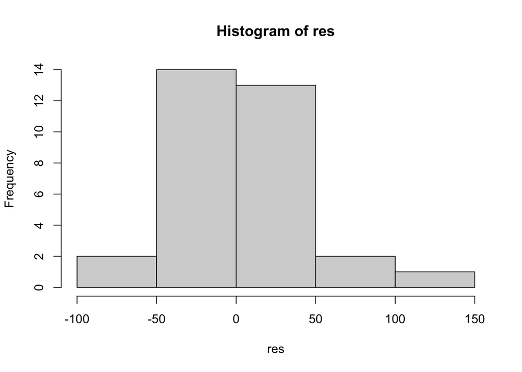

```r
# Tool 1 for checking normality
hist(res)
```

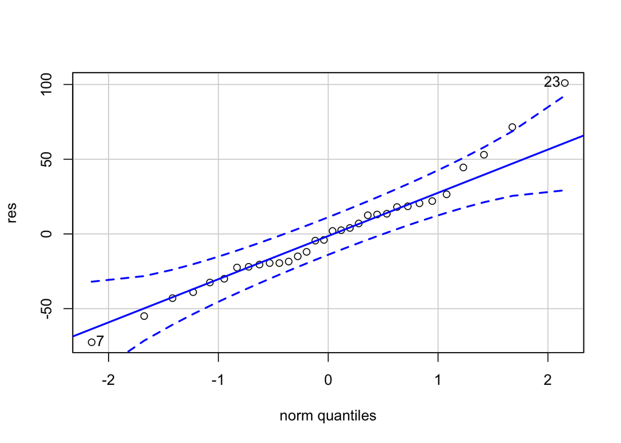

```
## [1] 23  7
```

```r
# Tool 2 for checking normality
qqPlot(res)
```

```r
# Tool 3 for checking normality

shapiro.test(res) ## W = 0.96575, p-value = 0.3911
```

```
##
##  Shapiro-Wilk normality test
##
## data:  res
## W = 0.96575, p-value = 0.3911
```

P-value (0.3911) > 0.05 so we cannot reject the null; suggests that the data are normal. Now lets check our next assumption.

**Homogeneity of Variance:** Run a Levene’s Test on the stacked data just like you have been doing for the last few weeks. I get a p-value of 0.9106.

```r
leveneTest(bac_colonies~washing_method,hand_wash) # F value = 0.1777, p-value =  0.9106
```

```
## Levene's Test for Homogeneity of Variance (center = median)
##       Df F value Pr(>F)
## group  3  0.1777 0.9106
##       28
```

```r
# some of you have been asking about the red output 'group coerced to factor' this is not an error, just a message saying the function leveneTest transformed your washing_method from a character to factor because the function has the argument that your factor needs to be a factor and not a character

str(hand_wash) # you can see that washing_method is considered a chr or factor in this dataset, if you followed the above code we transformed it into a factor after we called in the data
```

```
## 'data.frame':    32 obs. of  2 variables:
##  $ bac_colonies  : int  70 164 88 111 73 119 20 95 51 5 ...
##  $ washing_method: Factor w/ 4 levels "ab_soap","alcohol",..: 1 1 1 1 1 1 1 1 2 2 ...
```

P-value (0.9106) > 0.05, so the variances are equal.

So are the assumptions met? Or do you need to try a transformation? (refer to lab 6)

### Analyzing the ANOVA

Once we have confirmed that our assumptions are met we can analyze the ANOVA. For the hand washing data, we met both our assumptions of normality and homogeneity of variance, so we can analyze the model.

```r
# we actually already ran the anova when we created the residuals as a reminder we did it with:
# HINT: aov(y ~ x, data = dataset)
wash1 <- aov(bac_colonies ~ washing_method, data=hand_wash)
#So now we just need to get the results with:
summary(wash1) ## THIS IS THE ANOVA TABLE WE ARE REFERRING TO IN HW QUESTION 1E
```

```
##                Df Sum Sq Mean Sq F value  Pr(>F)
## washing_method  3  29882    9961   7.064 0.00111 **
## Residuals      28  39484    1410
## ---
## Signif. codes:  0 '***' 0.001 '**' 0.01 '*' 0.05 '.' 0.1 ' ' 1
```

As described in class, this table contains all of the information that was required to run the ANOVA. We see that we obtained an F-value of 7.064 and a p-value (0.001111) less than 𝛼=0.05 allowing us to reject the null hypothesis and conclude that at least one hand washing method is significantly more or less effective at removing bacterial colonies than the others.

### Post-hoc Comparisons

We just concluded from the above ANOVA that at least one of the means differ, but we often want to see which groups actually differ. We know we can’t do a bunch of t-tests because that will inflate our Type I error rate. We are instead going to use a method called a **Tukey-Kramer** test, which controls our Type I error rate. Here are some important notes about the Tukey-Kramer test:

- The Tukey-Kramer test assumes that you have already run an ANOVA and rejected your null hypothesis
- The Tukey-Kramer test does pairwise comparisons for all the groups we are testing and controls the family-wise Type I error rate so it is at most 𝛼=0.05 (it could be less).
- When your ANOVA is unbalanced (unequal sample sizes in each group), the Tukey-Kramer test is conservative, meaning that the family-wise Type I error is less than 𝛼 and it is harder for us to reject the null.
- The Tukey-Kramer test makes all of the same assumptions as the ANOVA

To run a Tukey-Kramer test for our hand-washing ANOVA

```r
# HINT: TukeyHSD(aov_model)
TukeyHSD(wash1)
```

```
##   Tukey multiple comparisons of means
##     95% family-wise confidence level
##
## Fit: aov(formula = bac_colonies ~ washing_method, data = hand_wash)
##
## $washing_method
##                  diff        lwr        upr     p adj
## alcohol-ab_soap -55.0 -106.26415  -3.735849 0.0319648
## soap-ab_soap     13.5  -37.76415  64.764151 0.8886944
## water-ab_soap    24.5  -26.76415  75.764151 0.5675942
## soap-alcohol     68.5   17.23585 119.764151 0.0055672
## water-alcohol    79.5   28.23585 130.764151 0.0012122
## water-soap       11.0  -40.26415  62.264151 0.9355196
```

A fancier way of doing this:

```r
# Use the function glht in the multcomp package

# HINT: glht(ANOVA_MODEL, linfct = mcp(FACTOR = "Tukey)
?glht() # you'll see you need to have a factor for your mcp(argument)

Post_hoc <- glht(wash1, linfct = mcp(washing_method = "Tukey")) # if washing_method is not a factor when you ran the wash1 anova, the glht() will not work

summary(Post_hoc)
```

```
##
##   Simultaneous Tests for General Linear Hypotheses
##
## Multiple Comparisons of Means: Tukey Contrasts
##
##
## Fit: aov(formula = bac_colonies ~ washing_method, data = hand_wash)
##
## Linear Hypotheses:
##                        Estimate Std. Error t value Pr(>|t|)
## alcohol - ab_soap == 0   -55.00      18.78  -2.929  0.03176 *
## soap - ab_soap == 0       13.50      18.78   0.719  0.88869
## water - ab_soap == 0      24.50      18.78   1.305  0.56753
## soap - alcohol == 0       68.50      18.78   3.648  0.00563 **
## water - alcohol == 0      79.50      18.78   4.234  0.00146 **
## water - soap == 0         11.00      18.78   0.586  0.93552
## ---
## Signif. codes:  0 '***' 0.001 '**' 0.01 '*' 0.05 '.' 0.1 ' ' 1
## (Adjusted p values reported -- single-step method)
```

```r
confint(Post_hoc) # shows your lower and upper CI bounds
```

```
##
##   Simultaneous Confidence Intervals
##
## Multiple Comparisons of Means: Tukey Contrasts
##
##
## Fit: aov(formula = bac_colonies ~ washing_method, data = hand_wash)
##
## Quantile = 2.7304
## 95% family-wise confidence level
##
##
## Linear Hypotheses:
##                        Estimate  lwr       upr
## alcohol - ab_soap == 0  -55.0000 -106.2666   -3.7334
## soap - ab_soap == 0      13.5000  -37.7666   64.7666
## water - ab_soap == 0     24.5000  -26.7666   75.7666
## soap - alcohol == 0      68.5000   17.2334  119.7666
## water - alcohol == 0     79.5000   28.2334  130.7666
## water - soap == 0        11.0000  -40.2666   62.2666
```

```r
cld(Post_hoc) #compact letter display of Tukey groups
```

```
## ab_soap alcohol    soap   water
##     "b"     "a"     "b"     "b"
```

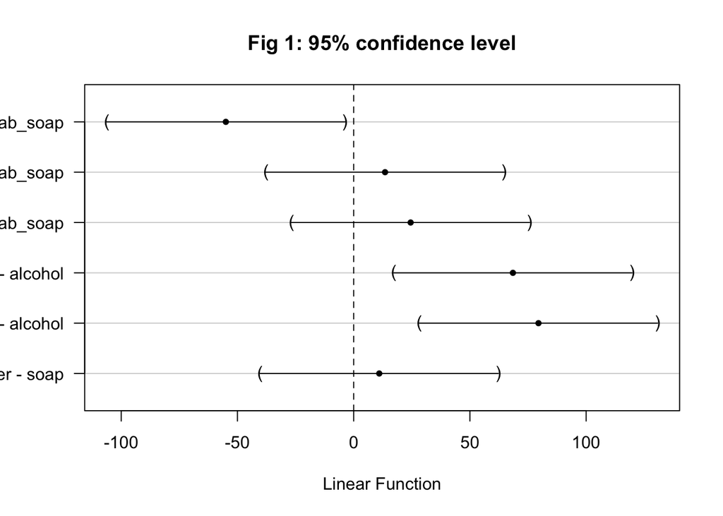

```r
plot(Post_hoc, main = "Fig 1: 95% confidence level") #confidence intervals plotted
```

```r
# the mean number of bacterial colonies on alcohol is significantly different than all other levels (alcohol = a, the rest of the levels = b)
# (has a different letter and CIs don't overlap with 0 and p-values significant)
```

It is also really useful to look at the letters at the bottom of the output. Notice that ab_soap, soap, water all are labeled with the letter “b” and alcohol is labeled with the letter “a”. If two levels share a letter they are not significantly different. If they do not share a letter they are significantly different. Notice that alcohol does not share a letter with any of the other levels; therefore the mean number of bacterial colonies on alcohol is significantly different than all other levels. Looking at our t-values we can see that there are significantly fewer bacterial colonies after hands are washed with alcohol.

Similarly, the Fig 1 displays the 95% family-wise CIs for each pairwise comparison. If the interval does not overlap with 0, we can conclude that the two treatments are different. Because we used the Tukey-Kramer test, if we repeated this experiment 100 times we would falsely reject one of our 6 pairwise comparisons no more than 5 times.

# HOMEWORK

### **Question 1**

The pollen of the corn (maize) plant is known to be a source of food to larval mosquitoes of the species Anopheles arabiensis, the main vector of malaria in Ethiopia. The production of maize has increased substantially in certain areas of Ethiopia recently, and over the same time malaria has entered in to new areas where it was previously rare. This raises the question, is the increase of maize cultivation partly responsible for the increase in malaria? One line of evidence is to look for a geographical association on a smaller spatial scale between maize production and malaria incidence. The data set **malaria_vs_maize.csv** contains information on several high-altitude sites in Ethiopia, with information about the level of cultivation of maize (low, medium or high) and the rate of malaria per 10,000 people. Use an ANOVA to test *whether there is a difference in the mean number of malaria cases between the three levels of cultivation*.

A. Clearly state your **null and alternative hypotheses**

B. Show me a **box plot** (or a means plot) of the data. How many levels are we testing?

C. Test the assumptions of normality and homogeneity of variance using the diagnostic plots (i.e. the **residual plot and the qqPlot**) and the **Shapiro-Wilk test and the Levene’s Test**. Based on these tests, what do you conclude about your normality and homogeneity of variance assumptions?

D. If your assumptions aren’t met try **transforming malaria_cases_per_1000**. After your transformation, **retest your assumptions using the transformed data** with diagnostic plots (i.e. the residual plot and the qqplot) and the Shapiro-Wilk test and the Levene’s Test. Find a transformation that allows for both assumptions to be met. Just report this transformation.

E. Run an **ANOVA on your transformed data**. Include the ANOVA table generated in the analysis. Using the ANOVA table, conclude whether the level of cultivation significantly affects the number of malaria cases. You don’t need to do any pairwise comparisons for this exercise.

### **Question 2**

The European cuckoo does not look after its own eggs, but instead lays them in the nests of birds of other species. Cuckoos sometimes have evolved to lay eggs that are colored similarly to the host birds’ eggs. Is the same true of size – do cuckoos lay eggs of different sizes in nests of different hosts? The data file **cuckooeggs.csv** contains data on the lengths of cuckoo eggs laid in a variety of other species’ nests.

Use an ANOVA to test for *a difference in cuckoo egg size for different host species*. Specifically:

A. Clearly state your **null and alternative hypotheses**

B. Show me a **box plot** (or a means plot) of the data. How many levels (groups) are we testing?

C. Test the **assumptions of normality and homogeneity of variance** using diagnostic plots (i.e. residuals plots and QQplots) and a Shapiro-Wilk test and a Levene’s Test. What do you conclude about your assumptions of normality and homogeneity of variance?

D. If your assumptions aren’t met try a transformation. Otherwise, proceed with your analysis.

E. Include the **ANOVA table** generated from the analysis. Conclude whether cuckoos lay different size eggs in different bird nests.

F. Perform a **Tukey-Kramer Test** for multiple comparisons. For what bird species does the cuckoo lay the significantly smallest eggs?

### **Question 3**

To get started on this exercise do the following. Save your current Rmarkdown file. You will not be adding any additional code to your Rmarkdown, just the text for the answers to this exercise.

Open the script **power_anova.R** in your R studio. You can do this by going to File →Open File…

You are interested in testing the efficacy of different “home remedies” as hangover cures. After testing many different home remedies, you believe that pickle juice is an effective hangover cure. You want to compare its effectiveness of curing hangovers to a control (nothing consumed) and a procedural control (water consumed). You measure effectiveness by the amount of time it takes for one’s head ache, sensitivity to bright light, and feelings of nausea to dissipate after taking one of the given treatments. You determined that this response variable was normally distributed and you want to run a one-way ANOVA. Your factor is home remedy and your levels are nothing, water, and pickle juice.

Based on some preliminary data you collected *pre-pandemic* on Saturday morning in IV, you suspect that the mean hangover recovery time after drinking pickle juice is around 124 minutes and the mean recovery time after not drinking anything is 180 minutes. Drinking water falls somewhere in between. Moreover, your preliminary analysis allowed you to estimate the standard deviation for each of these treatments as approximately ±70 minutes.

A. In 2 - 3 sentence, discuss two factors that could bias your experiment

B. Use a power analysis to determine *how many students you will need to sample* (for each level) to detect a *significant effect of pickle juice as a hangover cure* (given that one exists). Use the script **power_anova.R** to answer this question

- You can run all the code by typing “Control-a” (to highlight all the code) and “Control-r” (to run all the code). On a Mac, this will be “Command-a” and “Command-Enter”. It will take a few seconds to run, so be patient.
- From the plot that appears, determine approximately how many students you will need in each group to have a power of 0.8

C. A friend of yours has collected some additional data and suggests that the standard deviation of your three treatments is closer to 90 minutes. In your R code, *change the variable STD to 90 minutes* and determine how many students you would need to sample.

D. Finally, you stumble upon a jar of Kirkland pickle juice and some preliminary tests show you that it might drop your the approximate mean hangover recovery time to 74 minutes. With this new information, and with STD=90, *change PICKLEMEAN to 74* and re-run your power analysis. How many students do you need to sample now in order for your test to have a power of 0.8?

E. In one 1 to 2 sentences, draw some general conclusions on how the variance of your populations and the difference between your maximum and minimum mean of your levels influence the power of the ANOVA.